# LAB: Graphing using ggplot

### Plot attributes, mapping and `aes()`

- We can also add optional arguments for information to be shared across different components of the plot
- The two main arguments we typically use here are
- `data` - which is the name of the data frame we are working with, so `invert`
- `mapping` - which describes which columns of the data are used for different aspects of the plot
- We create a `mapping` by using the `aes` function, which stands for “aesthetic”, and then linking columns to pieces of the plot
- We’ll start with telling ggplot what value should be on the x and y axes
- Let’s plot the relationship between the `body_length_mm` of invertebrates to their `body_mass_g`
- note that I start a new line after each `,` and that Rstudio automatically indents for us. This improves readability and makes it easier to look for typos.

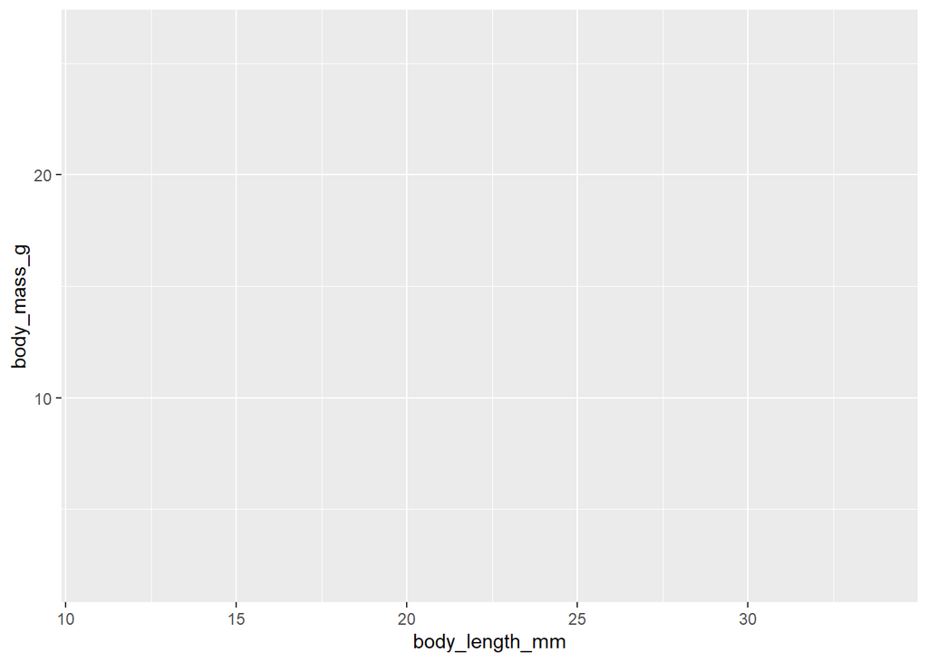

```r
ggplot(data = invert,
       mapping = aes(x = body_length_mm,
                     y = body_mass_g))
```

### Plot Layers

- We can add data to the plot using layers
- We do this by adding a `+` after the the `ggplot()` function and then adding something called a `geom`, which stands for `geometry`
- To make a scatter plot we use `geom_point()`

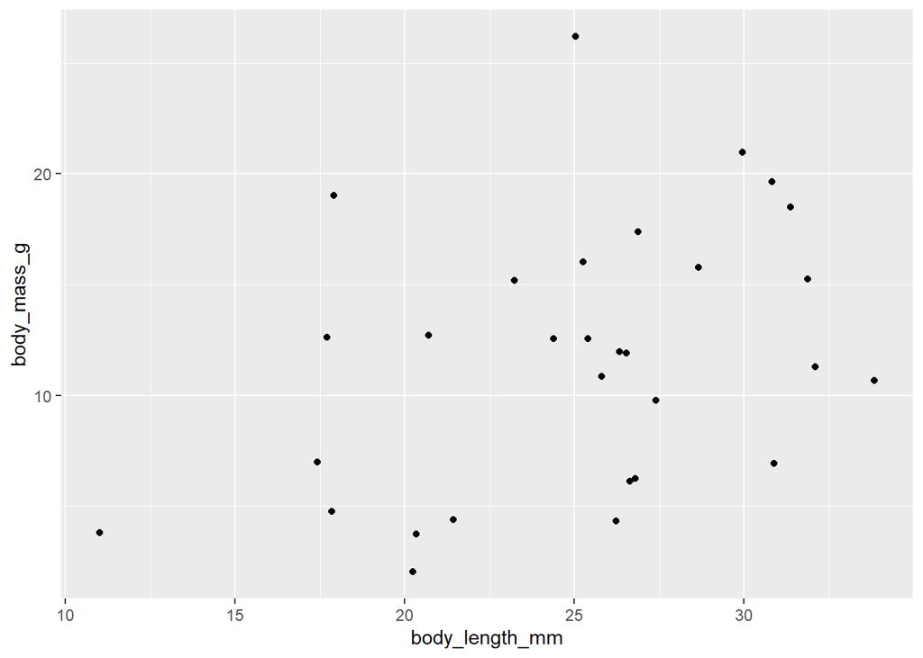

```r
ggplot(data = invert,
       mapping = aes(x = body_length_mm,
                     y = body_mass_g)) +
  geom_point()
```

- It is standard to hit `Enter` after the plus so that each layer shows up on its own line
- To change things about the layer we can pass additional arguments to the `geom`
- We can do things like change
  - the `size` of the points, we’ll set it to `3`
  - the `color` of the points, we’ll set it to `"blue"`
  - the transparency of the points, which is called `alpha`, we’ll set it to 0.5

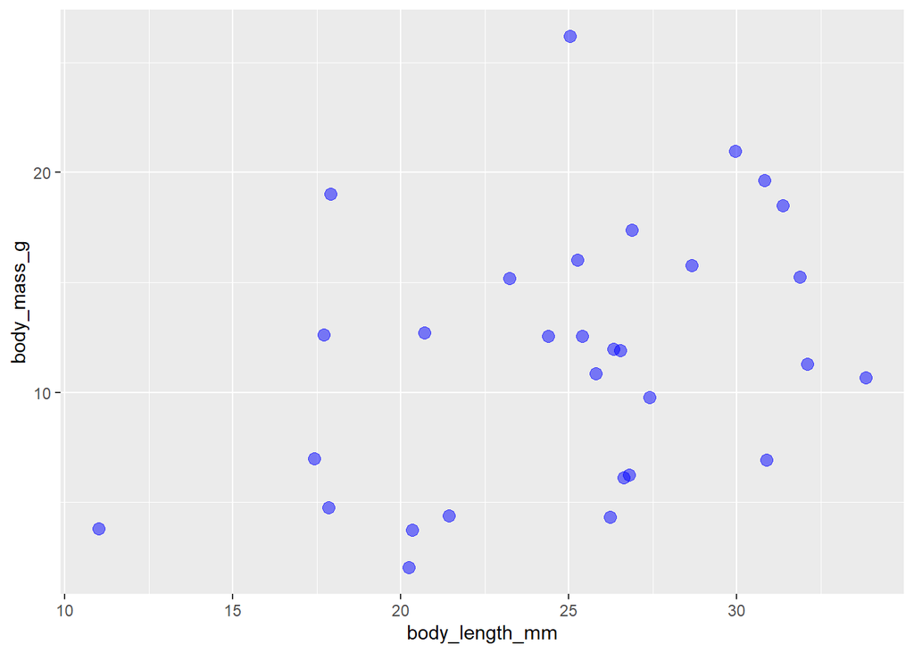

```r
ggplot(data = invert,
       mapping = aes(x = body_length_mm,
                     y = body_mass_g)) +
  geom_point(size = 3, color = "blue", alpha = 0.5)
```

- To add labels (like documentation for your graphs!) we use the `labs` function

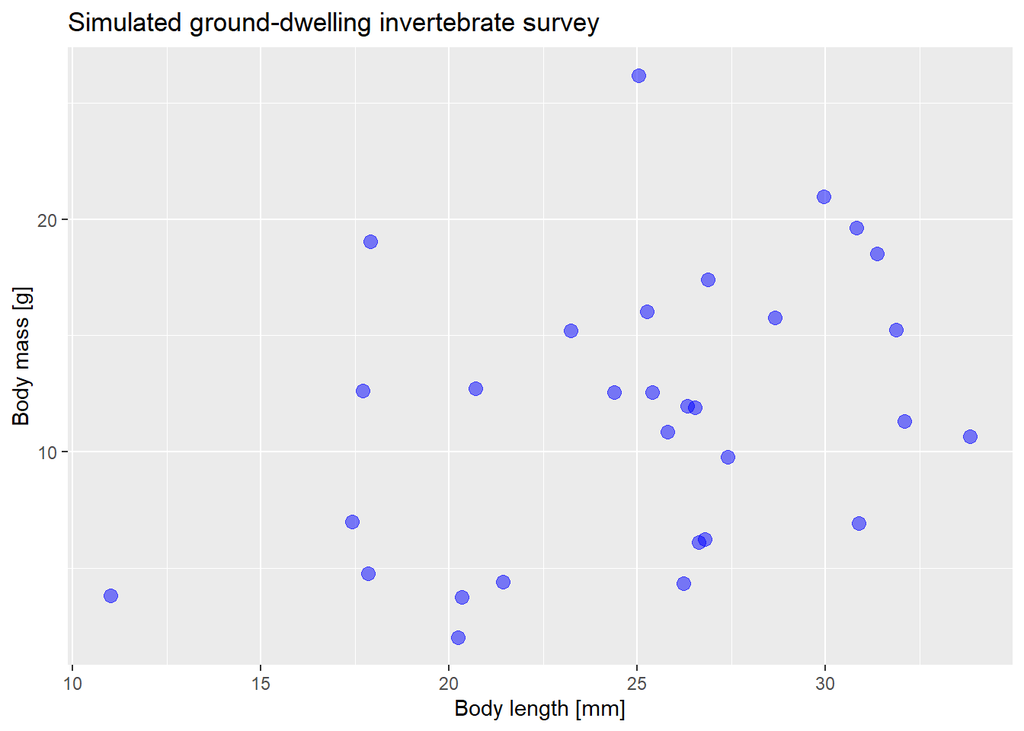

```r
ggplot(data = invert,
       mapping = aes(x = body_length_mm,
                     y = body_mass_g)) +
  geom_point(size = 3, color = "blue", alpha = 0.5) +
  labs(x = "Body length [mm]",
       y = "Body mass [g]",
       title = "Simulated ground-dwelling invertebrate survey")
```

# One Continuous Variable

Throughout the semester, we will want to see the distribution of one continuous variable. The two main ways we will do that is through:  
1. Histograms

2. Boxplots

## Histograms

- We can make a histogram of `body_mass_g` by modifying our earlier code.
- Note only **one** variable, so we remove the `y=...` part.
- We also change `geom_point()` to `geom_histogram`

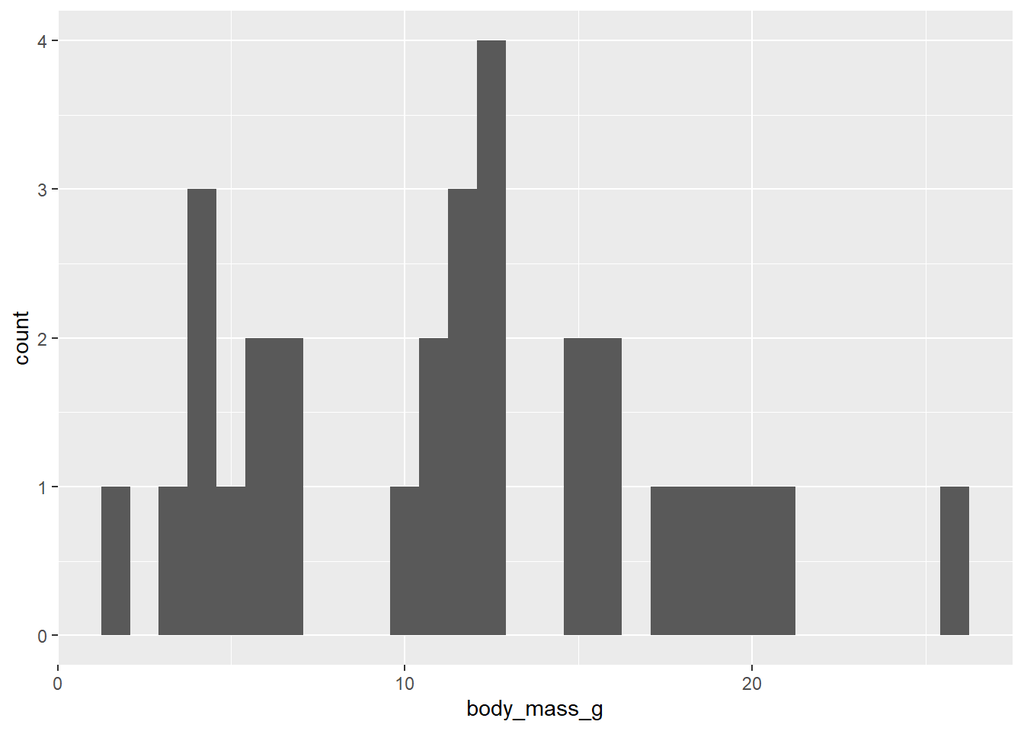

```r
ggplot(data = invert,
       mapping = aes(x = body_mass_g)) +
  geom_histogram()
```

### 5 bins

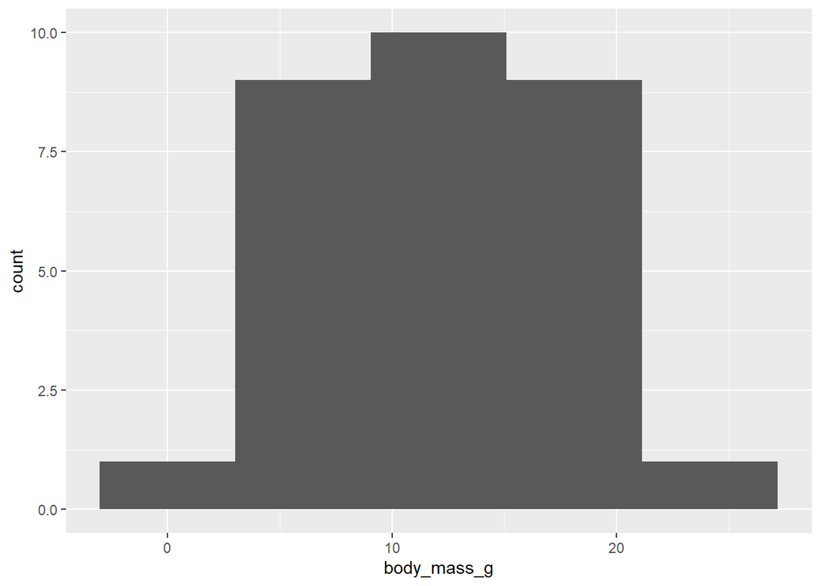

```r
ggplot(data = invert,
       mapping = aes(x = body_mass_g)) +
  geom_histogram(bins = 5)
```

- see that there are now 5 bins, but the “edges” of the bins are unclear

### Binwidth

- We can set the size of the bins with `binwidth` argument
- for example, let’s say we want bins that are 2.5 g across

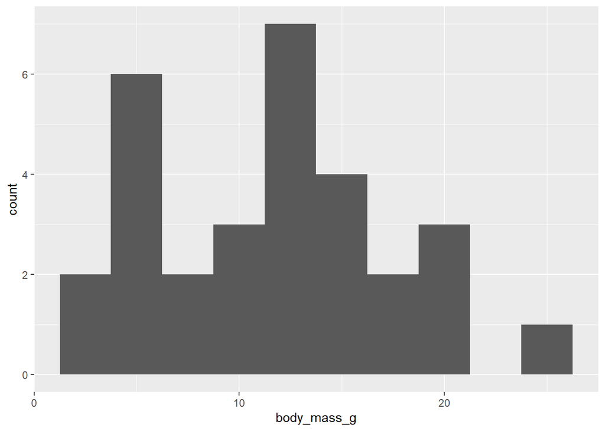

```r
ggplot(data = invert,
       mapping = aes(x = body_mass_g)) +
  geom_histogram(binwidth = 2.5)
```

### Histogram attributes

- We can change the attributes of the histogram output in similar ways as above
  - Common arguments are: `fill`, `color` (outline), `size` (outline), and `alpha` (transparency).
  - You can also explore different “themes”. Below is `theme_bw()`, but you can try `theme_classic()`, `theme_dark()`, `theme_void()`, etc.

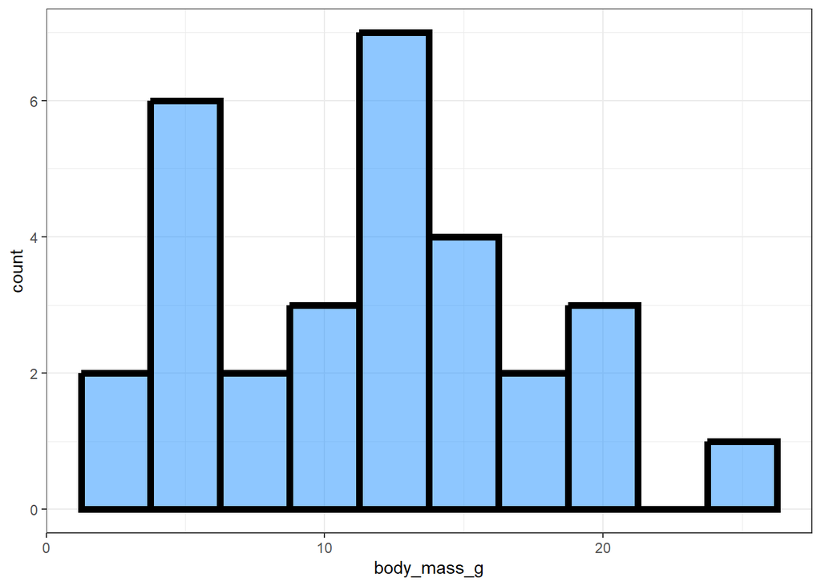

```r
ggplot(data = invert,
       mapping = aes(x = body_mass_g)) +
  geom_histogram(binwidth = 2.5,
                 fill = "dodgerblue",
                 color = "black",
                 size = 2,
                 alpha = 0.5) +
  theme_bw()
```

## Boxplots

- Boxplots summarize the data distribution
- AKA “Cat and Whisker” Plots

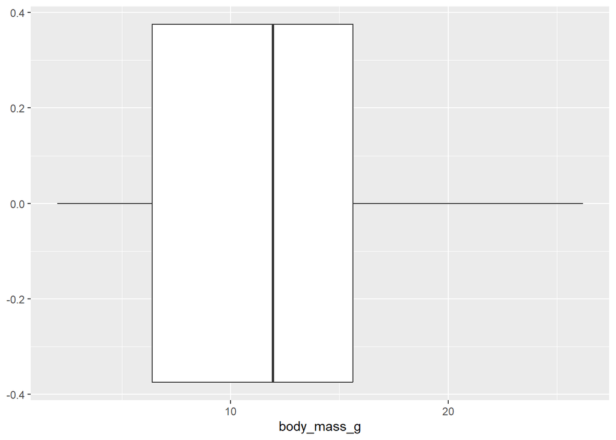

```r
ggplot(data = invert,
       mapping = aes(x = body_mass_g)) +
  geom_boxplot()
```

* whiskers: show minimum (left side) and maximum (right side) of data

- Box: shows where 50% of the data lies
- Line in middle of box is the median
- Useful to loo for normal distributions:
  - Symmetry of box, whiskers, etc.

### Boxplot attributes

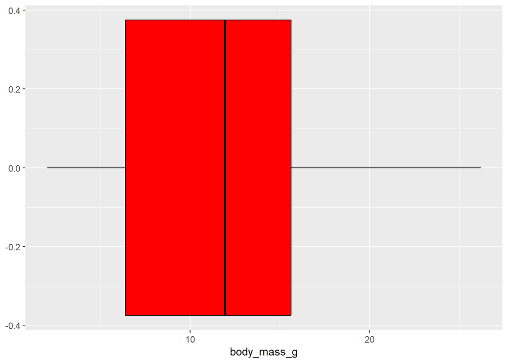

```r
ggplot(data = invert,
       mapping = aes(x = body_mass_g)) +
  geom_boxplot(fill = "red",
               color = "black")
```

## Density Plots

- Density plots show the full distribution
- i.e., a histogram has discrete bins, but a density plot is continuous

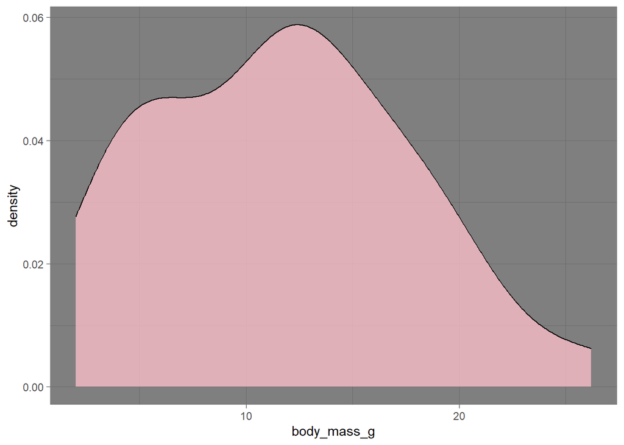

```r
ggplot(data = invert,
       mapping = aes(x = body_mass_g)) +
  geom_density(fill = "pink",
               alpha = 0.75) +
  theme_dark()
```

# One Continuous Variable, and Categories

## Boxplots

We will often want to compare the distributions between two groups. We can do this by modifying our boxplot code above by adding a grouping variable as our `y = ...` in the `aes()` function

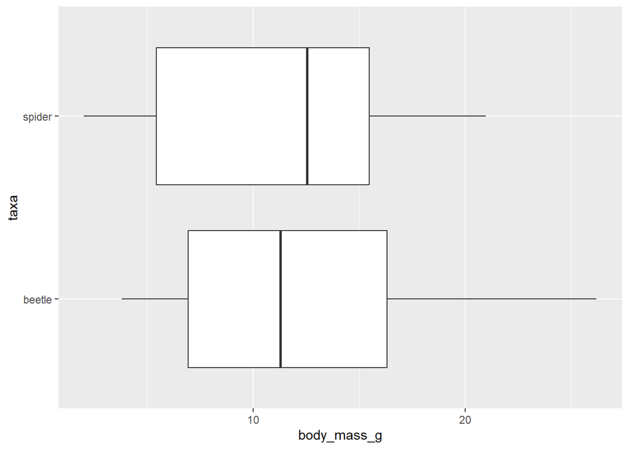

```r
ggplot(data = invert,
       mapping = aes(x = body_mass_g,
                     y = taxa)) +
  geom_boxplot()
```

- we can also vary the color/fill by taxa by including it in the `aes()` function

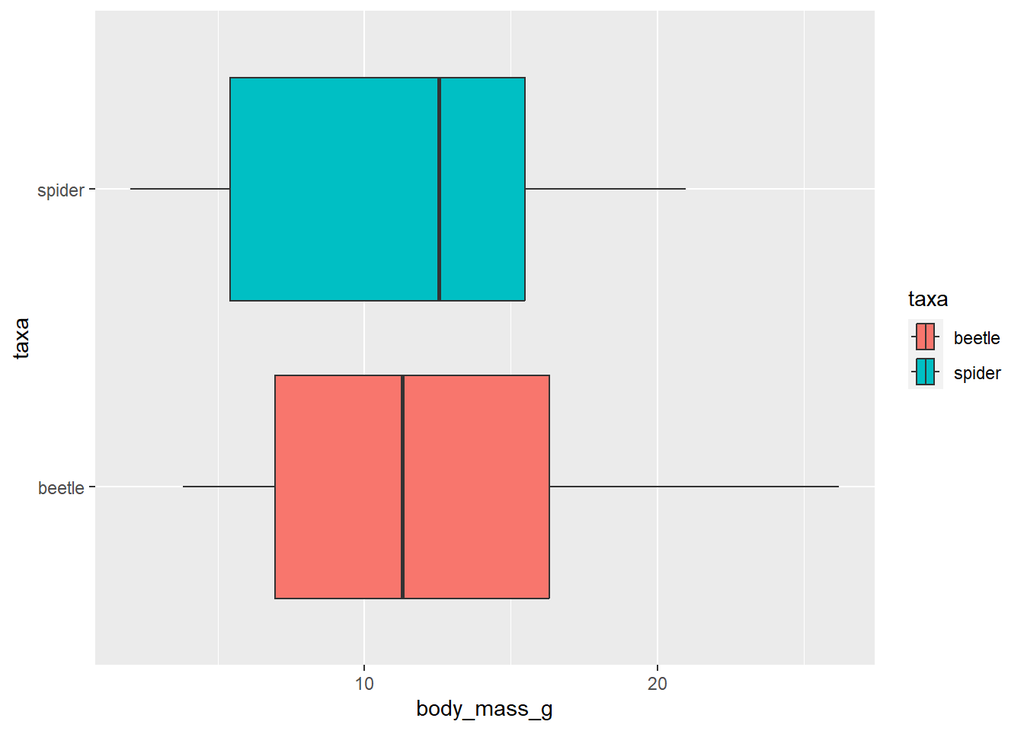

```r
ggplot(data = invert,
       mapping = aes(x = body_mass_g,
                     y = taxa,
                     fill = taxa)) +
  geom_boxplot()
```

* ggplot automatically picked two colors for us based on the values in the `taxa` column

### Manually

See a [list of colors](https://derekogle.com/NCGraphing/resources/colors) available in ggplot

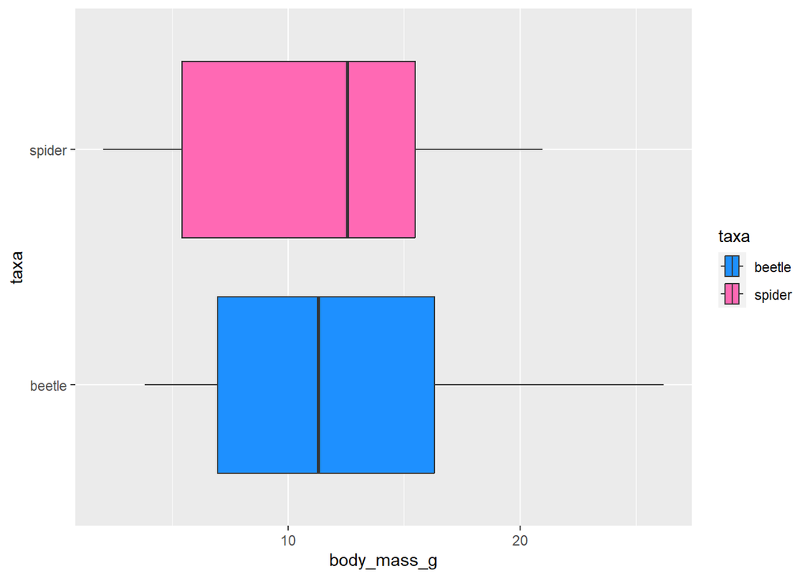

```r
ggplot(data = invert,
       mapping = aes(x = body_mass_g,
                     y = taxa,
                     fill = taxa)) +
  geom_boxplot() +
  scale_fill_manual(values = c("dodgerblue", "hotpink"))
```

- note that this **does not** work if you put it in the `geom_boxplot()` argument:

```r
ggplot(data = invert,
       mapping = aes(x = body_mass_g,
                     y = taxa)) +
  geom_boxplot(fill = taxa)
```

- Likewise, if you put a fill/color argument in the `geom_boxplot()` function, it will overwrite what you mapped above

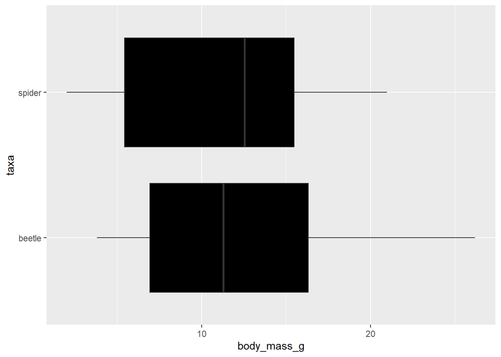

```r
ggplot(data = invert,
       mapping = aes(x = body_mass_g,
                     y = taxa,
                     fill = taxa)) +
  geom_boxplot(fill = "black")
```

### Categorical vs. continuous variables

- Our data has the results of three surveys across months
- we may want to see if there are different distributions across months

```
## Warning: The following aesthetics were dropped during statistical transformation: fill
## ℹ This can happen when ggplot fails to infer the correct grouping structure in
##   the data.
## ℹ Did you forget to specify a `group` aesthetic or to convert a numerical
##   variable into a factor?
```

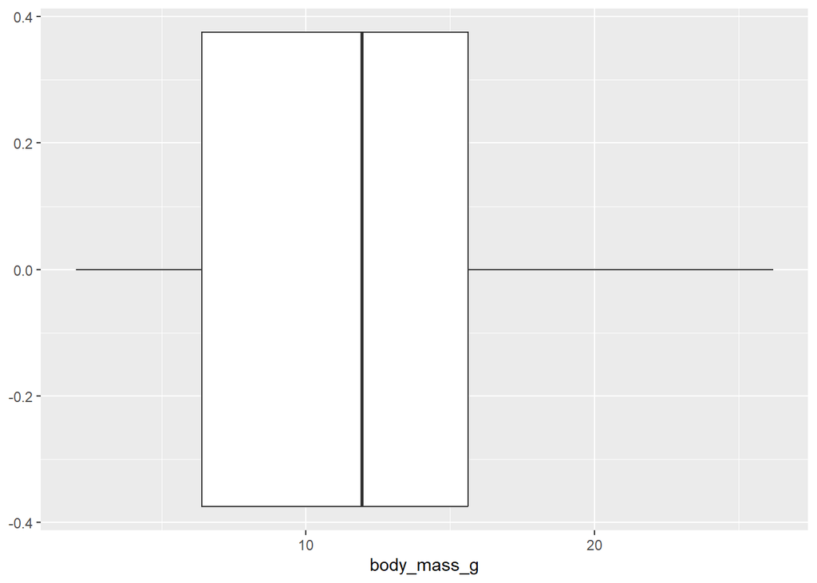

```r
ggplot(data = invert,
       mapping = aes(x = body_mass_g,
                     fill = month)) +
  geom_boxplot()
```

- this didn’t work because `month` is a number, which R interprets as a continuous variable.
- notice the warning discusses “group” structure of the data
- we can get around this a number of ways.
- the easiest at this point is to force month to be a `factor` (what R calls a categorical variable).

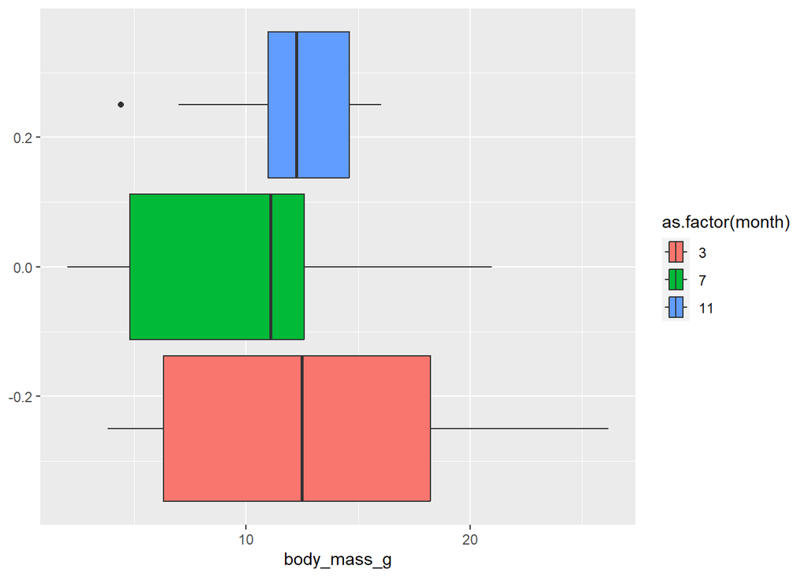

```r
ggplot(data = invert,
       mapping = aes(x = body_mass_g,
                     fill = as.factor(month))) +
  geom_boxplot()
```

## Histograms

- We can also do a similar thing with histograms.
- note that we need to **remove** the `y=...` argument, and we also need to add `position = "identity"` to the histogram call.
  - otherwise the counts are “stacked” and the display is misleading

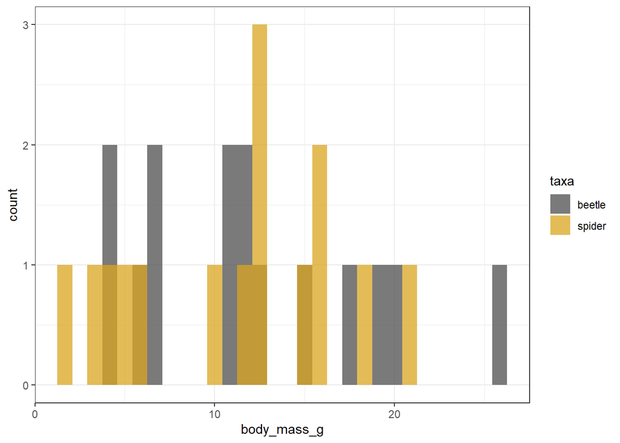

```r
ggplot(data = invert,
       mapping = aes(x = body_mass_g,
                     fill = taxa)) +
  geom_histogram(position = "identity",
                 alpha = 0.75) +
  scale_fill_manual(values = c("grey30", "goldenrod")) +
  theme_bw()
```

# Two Continuous Variables

## Scatter Plots

- Display two continuous variables by mapping them to `x` and `y`

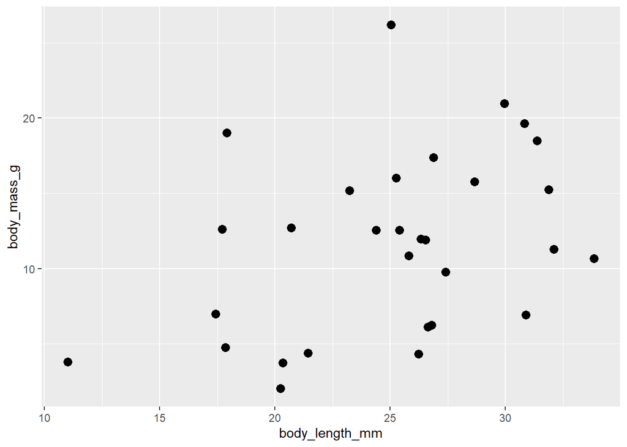

```r
ggplot(data = invert,
       mapping = aes(x = body_length_mm,
                     y = body_mass_g)) +
  geom_point(size = 3)
```

### map attributes to other columns

#### Color

- Using a categorical variable
- Gives discrete colors
  - i.e., “red”, or “blue”

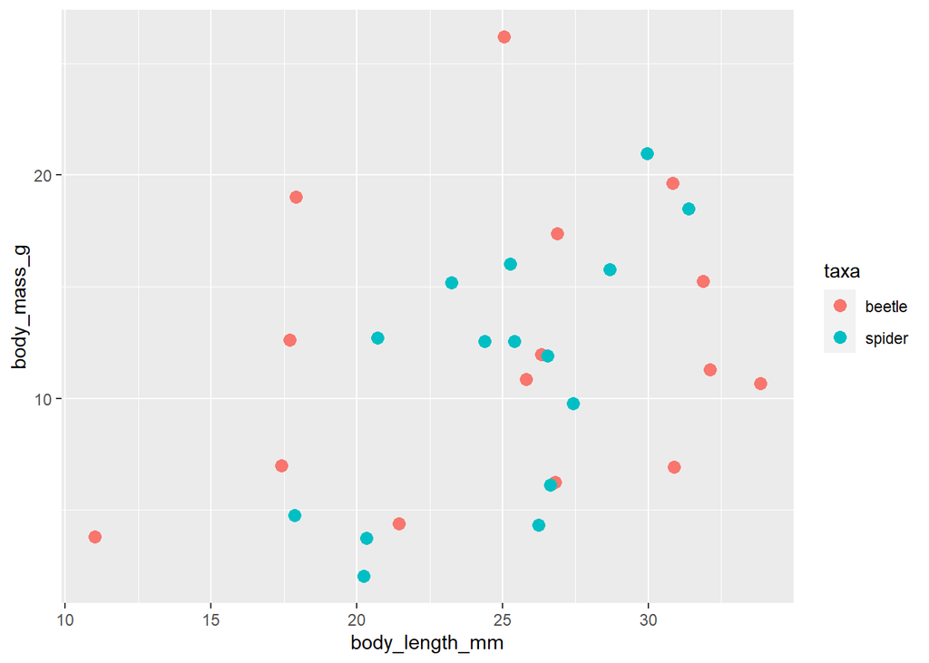

```r
ggplot(data = invert,
       mapping = aes(x = body_length_mm,
                     y = body_mass_g,
                     color = taxa)) +
  geom_point(size = 3)
```

- Using a continuous variable
- gives “shades” of one color, based on value

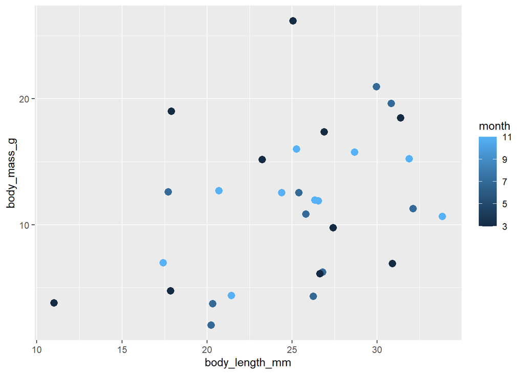

```r
ggplot(data = invert,
       mapping = aes(x = body_length_mm,
                     y = body_mass_g,
                     color = month)) +
  geom_point(size = 3)
```

#### Shape

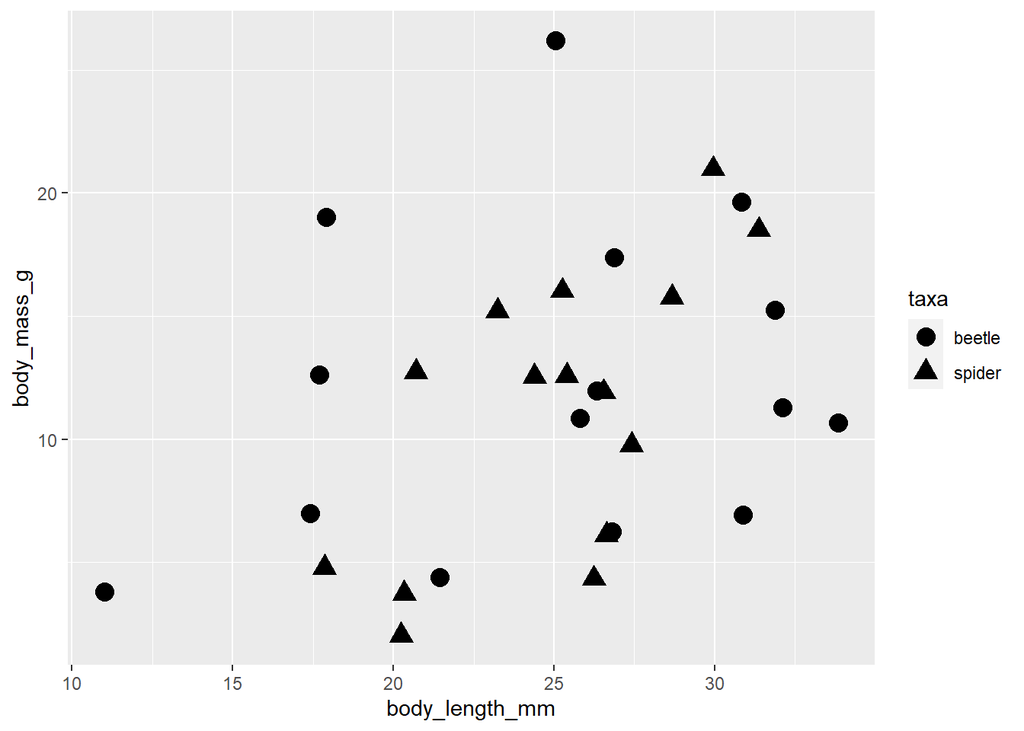

```r
ggplot(data = invert,
       mapping = aes(x = body_length_mm,
                     y = body_mass_g,
                     shape = taxa)) +
  geom_point(size = 4)
```

#### Shape + color

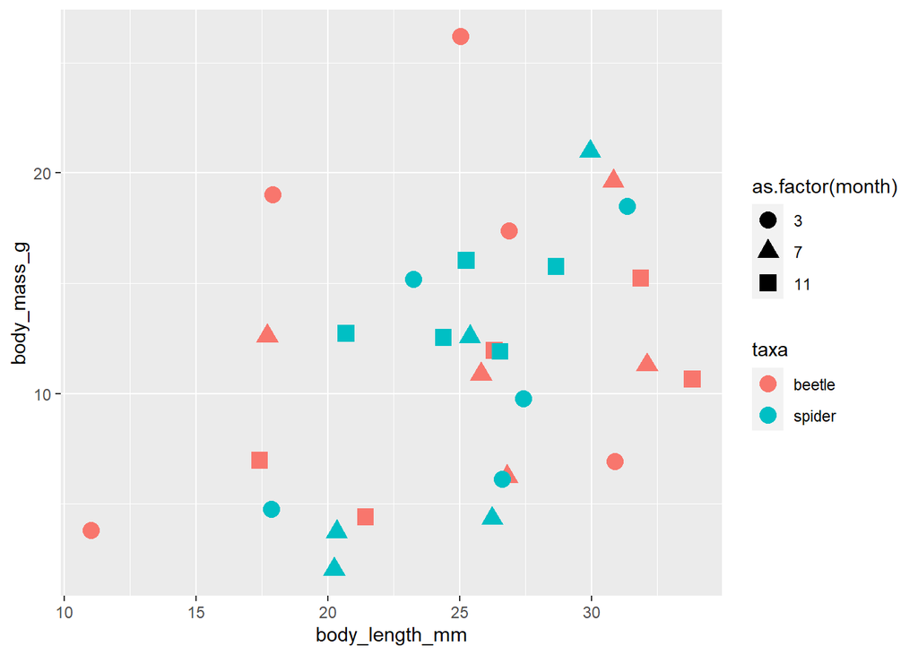

```r
ggplot(data = invert,
       mapping = aes(x = body_length_mm,
                     y = body_mass_g,
                     color = taxa,
                     shape = as.factor(month))) +
  geom_point(size = 4)
```

## `geom_smooth()`

- We will often want to estimate the relationship between our predictor (`x`) and our response (`y`).
- do this with `geom_smooth()`

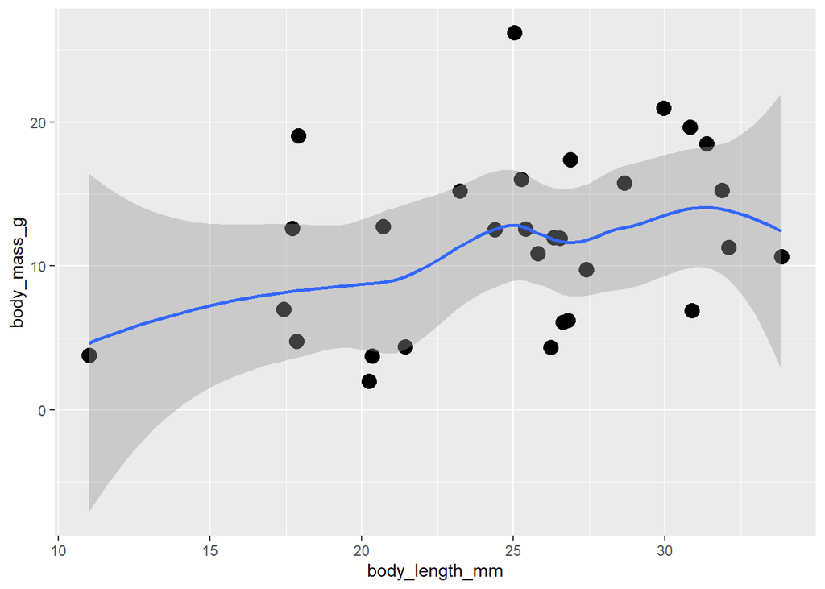

```r
ggplot(data = invert,
       mapping = aes(x = body_length_mm,
                     y = body_mass_g)) +
  geom_point(size = 4) +
  geom_smooth()
```

- the default is a “squiggly line”
- we will limit ourselves to linear relationships, so add `method = "lm"`

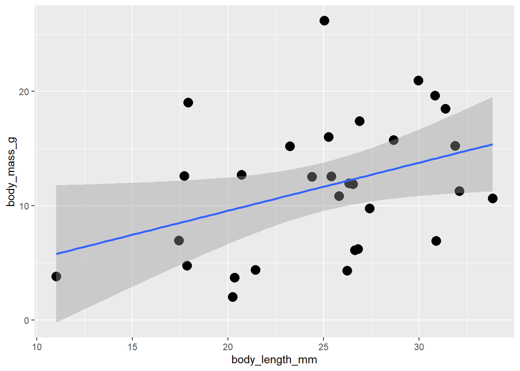

```r
ggplot(data = invert,
       mapping = aes(x = body_length_mm,
                     y = body_mass_g)) +
  geom_point(size = 4) +
  geom_smooth(method = "lm")
```

- `geom_smooth()` inherits other aspects from aes.
- add a smooth for both taxa:

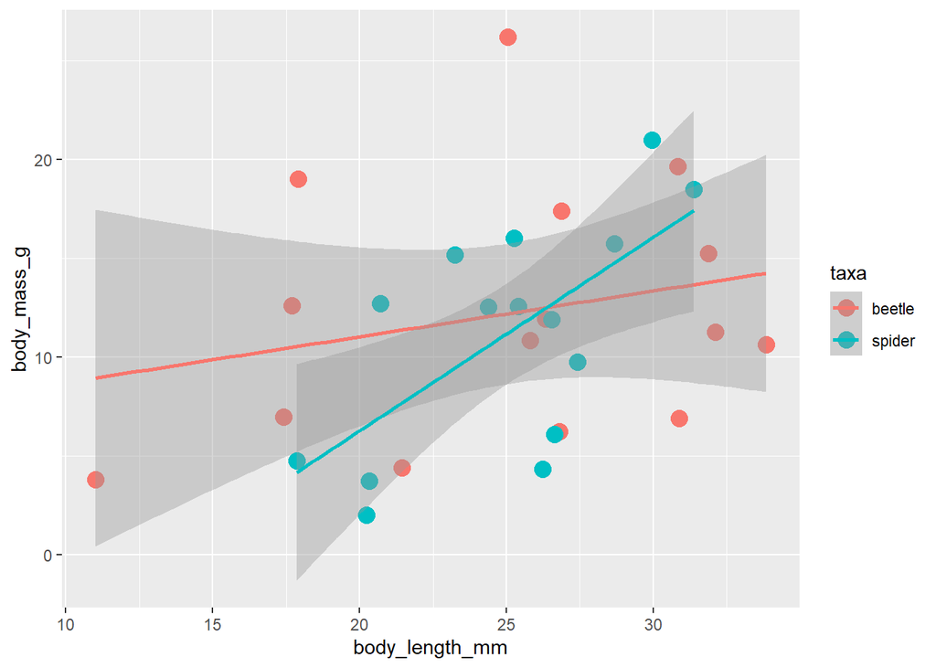

```r
ggplot(data = invert,
       mapping = aes(x = body_length_mm,
                     y = body_mass_g,
                     color = taxa)) +
  geom_point(size = 4) +
  geom_smooth(method = "lm")
```

## Facets

In any of the plots, it is also possible to add facets, which gives each group their own panel:

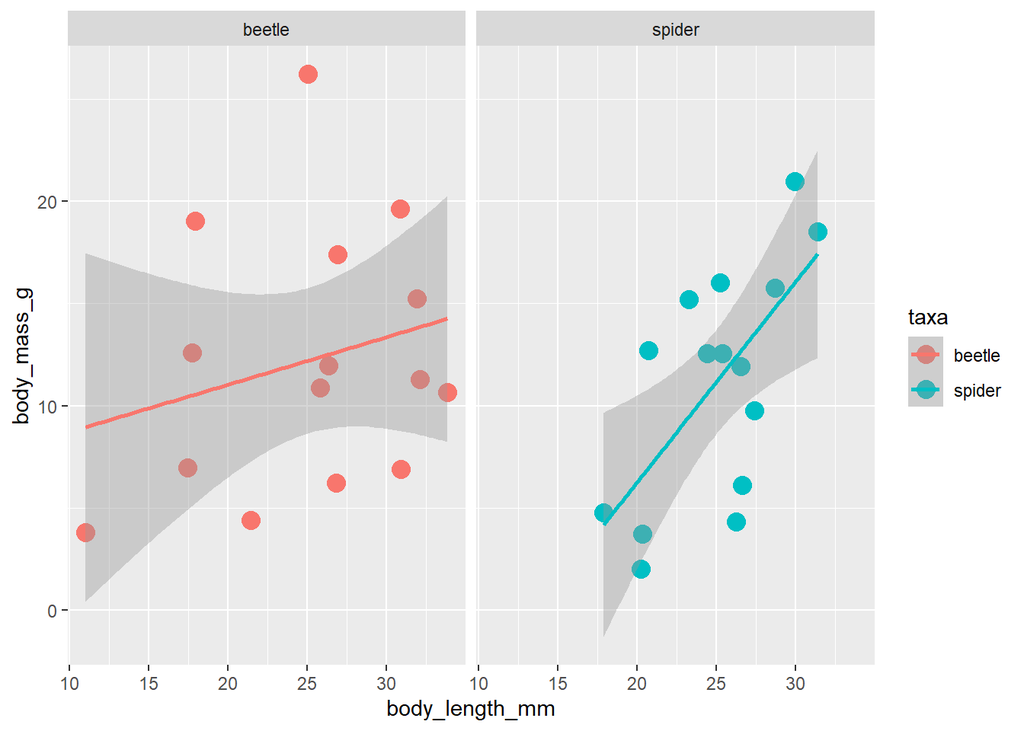

```r
ggplot(data = invert,
       mapping = aes(x = body_length_mm,
                     y = body_mass_g,
                     color = taxa)) +
  geom_point(size = 4) +
  geom_smooth(method = "lm") +
  facet_wrap(~taxa)
```

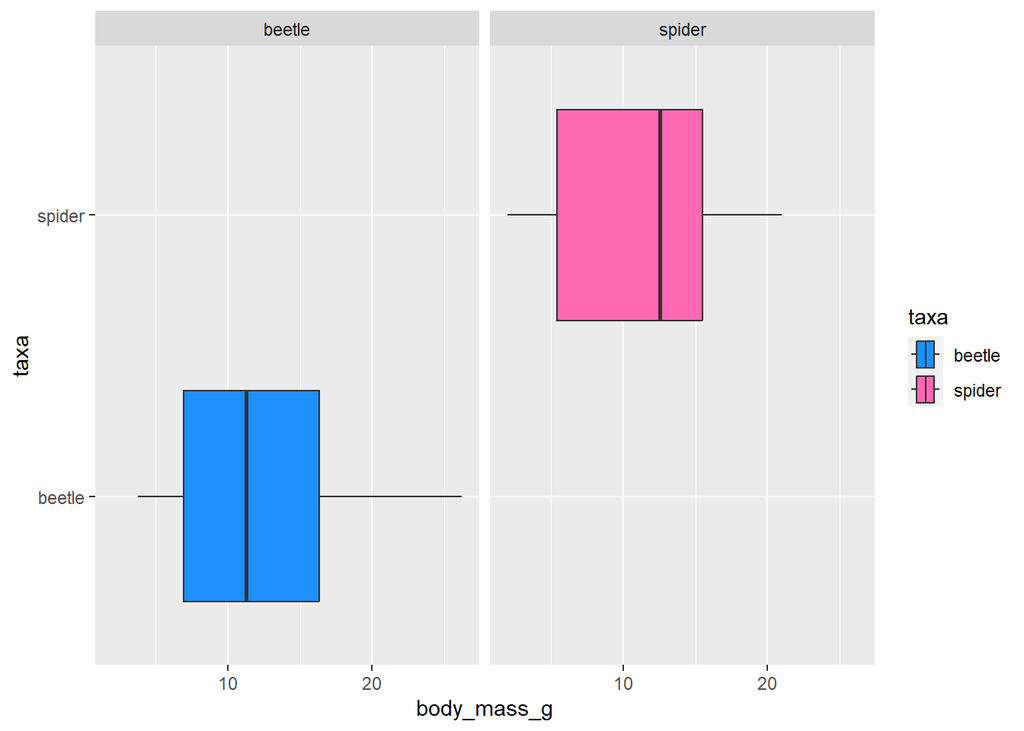

```r
ggplot(data = invert,
       mapping = aes(x = body_mass_g,
                     y = taxa,
                     fill = taxa)) +
  geom_boxplot() +
  scale_fill_manual(values = c("dodgerblue", "hotpink")) +
  facet_wrap(~taxa)
```

- can also add a different variable
- this helps to visualize when we have 2+ grouping variables

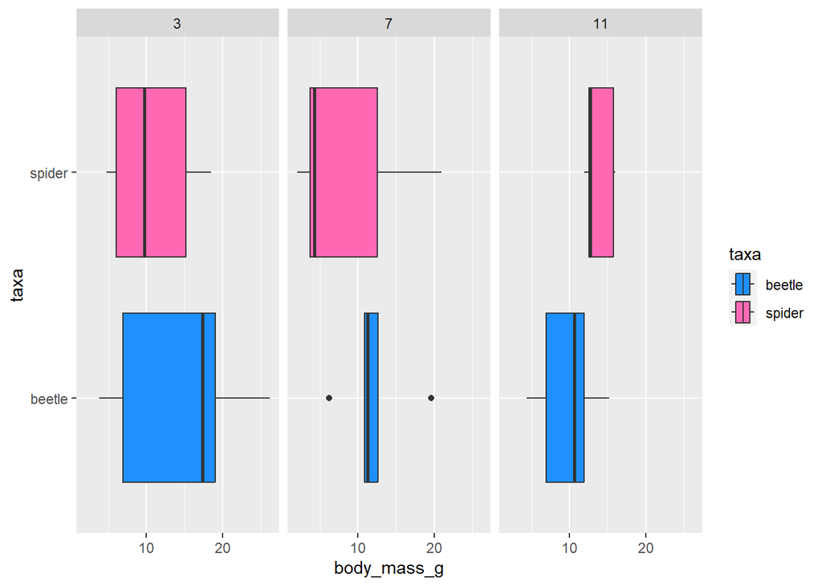

```r
ggplot(data = invert,
       mapping = aes(x = body_mass_g,
                     y = taxa,
                     fill = taxa)) +
  geom_boxplot() +
  scale_fill_manual(values = c("dodgerblue", "hotpink")) +
  facet_wrap(~month)
```

## Coda

You should now be able to finish the homework. The below information is provided for your personal edification

### Grammar of graphics

- Uniquely describe any plot based on a defined set of information
- Leland Wilkinson
- Geometric object(s)
  - Data
  - Mapping
  - Statistical transformation
  - Position (allows you to shift objects, e.g., spread out overlapping data points)
- Facets
- Coordinates (coordinate systems other than cartesian, also allows zooming)

### Saving plots as new files

- `ggsave()` function saves whatever the last plot you made was.
- let’s rerun this code:

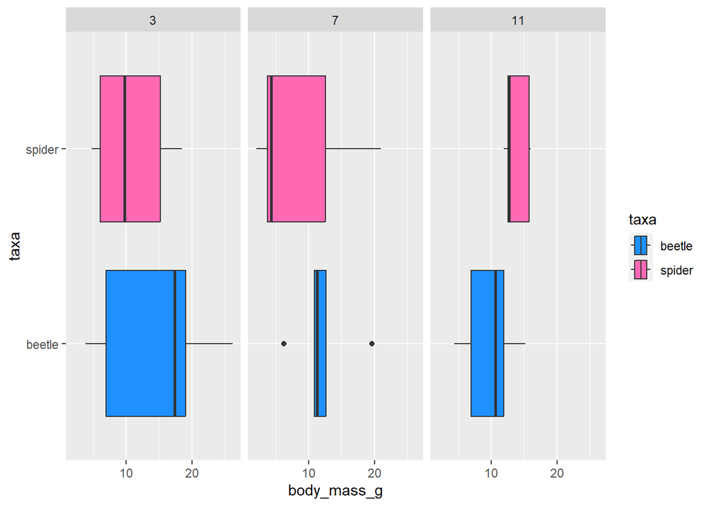

```r
ggplot(data = invert,
       mapping = aes(x = body_mass_g,
                     y = taxa,
                     fill = taxa)) +
  geom_boxplot() +
  scale_fill_manual(values = c("dodgerblue", "hotpink")) +
  facet_wrap(~month)
```

- we will now save it into the home directory of our project and name the file:

```r
ggsave("invert_by_month_taxa.jpg")
```

- The type of the file is determined by the file extension

```r
ggsave("invert_by_month_taxa.jpg")
```

```r
ggsave("homework/invert_by_month_taxa.png")
```

- Check your folder to make sure the file is there.
- Open it to see how it looks
- You may want to delete this from your homework folder so you don’t get confused later.